# M4-Data AR MA manual

   ```r
   TSA::eacf(arma11)
   ```

   ```
   ## AR/MA
   ##   0 1 2 3 4 5 6 7 8 9 10 11 12 13
   ## 0 x x x x x x x o x x x  x  o  o
   ## 1 x o o o o o o o o o o  o  o  o
   ## 2 x x o o o o o o o o o  o  o  o
   ## 3 x o o o o o o o o o o  o  o  o
   ## 4 x x x x o o o o o o o  o  o  o
   ## 5 o x x x x o o o o o o  o  o  o
   ## 6 x o x o x o o o o o o  o  o  o
   ## 7 x o x o x o o o o o o  o  o  o
   ```

5. Scatter plot Yt dan Yt-1 dan korelasinya

   ```r
   #Yt
   yt_arma <- arma11[-1]
   yt_arma
   ```

   ```
   ##   [1]  3.60063126  2.96280647  1.35176779 -0.17581640 -0.48580998 -2.61530283
   ##   [7] -3.48356186 -1.51233913  1.05099693  1.67687161  1.19693725  2.45431360
   ##  [13]  3.96934346  2.05763565  0.84915986  1.33073020  1.37764303  1.12852287
   ##  [19]  0.68563712  0.20064420 -0.13435713 -0.52058893 -0.66025843  0.45513261
   ##  [25]  3.28305975  2.98802538  1.60614408  0.54258381  2.08062252  1.46307344
   ##  [31] -2.09157852 -2.48817867 -3.82657046 -5.22247672 -2.82687780 -0.06648461
   ##  [37]  1.11372612 -1.17595409 -2.50568225 -3.78987343 -2.51730935 -1.93969913
   ##  [43] -4.20649022 -3.39463990 -0.49374120 -0.29976170 -0.87648866 -0.58434088
   ##  [49] -0.81458249  0.29436326  1.18870392 -0.29976125 -1.99772918 -1.90468270
   ##  [55] -0.57336756 -0.68779557 -1.27431704 -1.63406802 -3.10748012 -1.97002613
   ##  [61] -0.60996158 -0.01332423 -3.08686758 -4.81076478 -3.19773866 -1.25857935
   ##  [67] -1.33589694 -1.94136410 -1.22386499 -0.34017091  1.07831901  2.87865406
   ##  [73]  2.02059128  1.18975006  0.10966441 -0.47956754 -2.00749938 -2.44557262
   ##  [79] -1.29457506 -1.01698710 -0.98038068  1.92773423  1.15326400  0.29024042
   ##  [85] -0.61892227  0.51692849  0.74755840  0.12455925 -0.39616302  0.52896452
   ```

   [output cut: 35 more lines]

   ```r
   #Yt-1
   yt_1_arma <- arma11[-300]
   yt_1_arma
   ```

   ```
   ##   [1]  4.20792485  3.60063126  2.96280647  1.35176779 -0.17581640 -0.48580998
   ##   [7] -2.61530283 -3.48356186 -1.51233913  1.05099693  1.67687161  1.19693725
   ##  [13]  2.45431360  3.96934346  2.05763565  0.84915986  1.33073020  1.37764303
   ##  [19]  1.12852287  0.68563712  0.20064420 -0.13435713 -0.52058893 -0.66025843
   ##  [25]  0.45513261  3.28305975  2.98802538  1.60614408  0.54258381  2.08062252
   ##  [31]  1.46307344 -2.09157852 -2.48817867 -3.82657046 -5.22247672 -2.82687780
   ##  [37] -0.06648461  1.11372612 -1.17595409 -2.50568225 -3.78987343 -2.51730935
   ##  [43] -1.93969913 -4.20649022 -3.39463990 -0.49374120 -0.29976170 -0.87648866
   ##  [49] -0.58434088 -0.81458249  0.29436326  1.18870392 -0.29976125 -1.99772918
   ##  [55] -1.90468270 -0.57336756 -0.68779557 -1.27431704 -1.63406802 -3.10748012
   ##  [61] -1.97002613 -0.60996158 -0.01332423 -3.08686758 -4.81076478 -3.19773866
   ##  [67] -1.25857935 -1.33589694 -1.94136410 -1.22386499 -0.34017091  1.07831901
   ##  [73]  2.87865406  2.02059128  1.18975006  0.10966441 -0.47956754 -2.00749938
   ##  [79] -2.44557262 -1.29457506 -1.01698710 -0.98038068  1.92773423  1.15326400
   ##  [85]  0.29024042 -0.61892227  0.51692849  0.74755840  0.12455925 -0.39616302
   ```

   [output cut: 35 more lines]

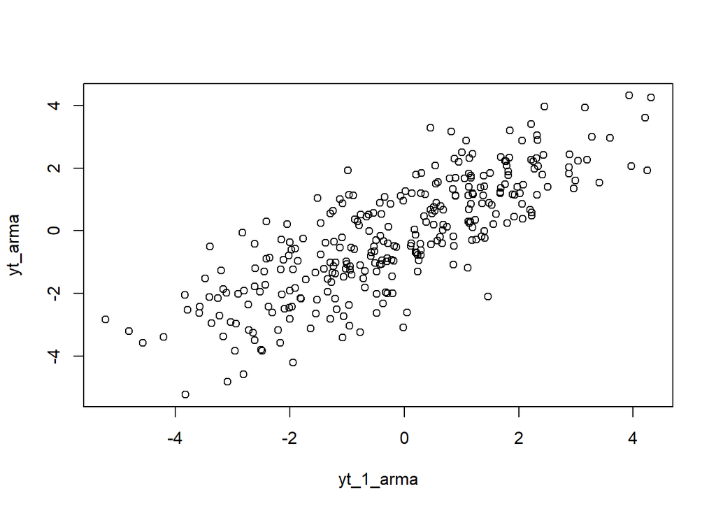

   ```r
   #Plot
   plot(y=yt_arma,x=yt_1_arma)
   ```

   ```r
   #Korelasi
   cor(yt_arma,yt_1_arma)
   ```

   ```
   ## [1] 0.7999012
   ```

   Berdasarkan plot tersebut, terlihat hubungan tren positif antara Yt dan Yt-1. Adapun korelasi yang didapatkan sebesar 0.7999012.
6. Scatter Yt dan Yt-2 dan korelasinya

   ```r
   #Yt
   yt_arma2 <- arma11[-c(1,2)]
   yt_arma2
   ```

   ```
   ##   [1]  2.96280647  1.35176779 -0.17581640 -0.48580998 -2.61530283 -3.48356186
   ##   [7] -1.51233913  1.05099693  1.67687161  1.19693725  2.45431360  3.96934346
   ##  [13]  2.05763565  0.84915986  1.33073020  1.37764303  1.12852287  0.68563712
   ##  [19]  0.20064420 -0.13435713 -0.52058893 -0.66025843  0.45513261  3.28305975
   ##  [25]  2.98802538  1.60614408  0.54258381  2.08062252  1.46307344 -2.09157852
   ##  [31] -2.48817867 -3.82657046 -5.22247672 -2.82687780 -0.06648461  1.11372612
   ##  [37] -1.17595409 -2.50568225 -3.78987343 -2.51730935 -1.93969913 -4.20649022
   ##  [43] -3.39463990 -0.49374120 -0.29976170 -0.87648866 -0.58434088 -0.81458249
   ##  [49]  0.29436326  1.18870392 -0.29976125 -1.99772918 -1.90468270 -0.57336756
   ##  [55] -0.68779557 -1.27431704 -1.63406802 -3.10748012 -1.97002613 -0.60996158
   ##  [61] -0.01332423 -3.08686758 -4.81076478 -3.19773866 -1.25857935 -1.33589694
   ##  [67] -1.94136410 -1.22386499 -0.34017091  1.07831901  2.87865406  2.02059128
   ##  [73]  1.18975006  0.10966441 -0.47956754 -2.00749938 -2.44557262 -1.29457506
   ##  [79] -1.01698710 -0.98038068  1.92773423  1.15326400  0.29024042 -0.61892227
   ##  [85]  0.51692849  0.74755840  0.12455925 -0.39616302  0.52896452  0.62866310
   ```

   [output cut: 35 more lines]

   ```r
   #Yt-2
   yt_2_arma <- arma11[-c(299,300)]
   yt_2_arma
   ```

   ```
   ##   [1]  4.20792485  3.60063126  2.96280647  1.35176779 -0.17581640 -0.48580998
   ##   [7] -2.61530283 -3.48356186 -1.51233913  1.05099693  1.67687161  1.19693725
   ##  [13]  2.45431360  3.96934346  2.05763565  0.84915986  1.33073020  1.37764303
   ##  [19]  1.12852287  0.68563712  0.20064420 -0.13435713 -0.52058893 -0.66025843
   ##  [25]  0.45513261  3.28305975  2.98802538  1.60614408  0.54258381  2.08062252
   ##  [31]  1.46307344 -2.09157852 -2.48817867 -3.82657046 -5.22247672 -2.82687780
   ##  [37] -0.06648461  1.11372612 -1.17595409 -2.50568225 -3.78987343 -2.51730935
   ##  [43] -1.93969913 -4.20649022 -3.39463990 -0.49374120 -0.29976170 -0.87648866
   ##  [49] -0.58434088 -0.81458249  0.29436326  1.18870392 -0.29976125 -1.99772918
   ##  [55] -1.90468270 -0.57336756 -0.68779557 -1.27431704 -1.63406802 -3.10748012
   ##  [61] -1.97002613 -0.60996158 -0.01332423 -3.08686758 -4.81076478 -3.19773866
   ##  [67] -1.25857935 -1.33589694 -1.94136410 -1.22386499 -0.34017091  1.07831901
   ##  [73]  2.87865406  2.02059128  1.18975006  0.10966441 -0.47956754 -2.00749938
   ##  [79] -2.44557262 -1.29457506 -1.01698710 -0.98038068  1.92773423  1.15326400
   ##  [85]  0.29024042 -0.61892227  0.51692849  0.74755840  0.12455925 -0.39616302
   ```

   [output cut: 35 more lines]

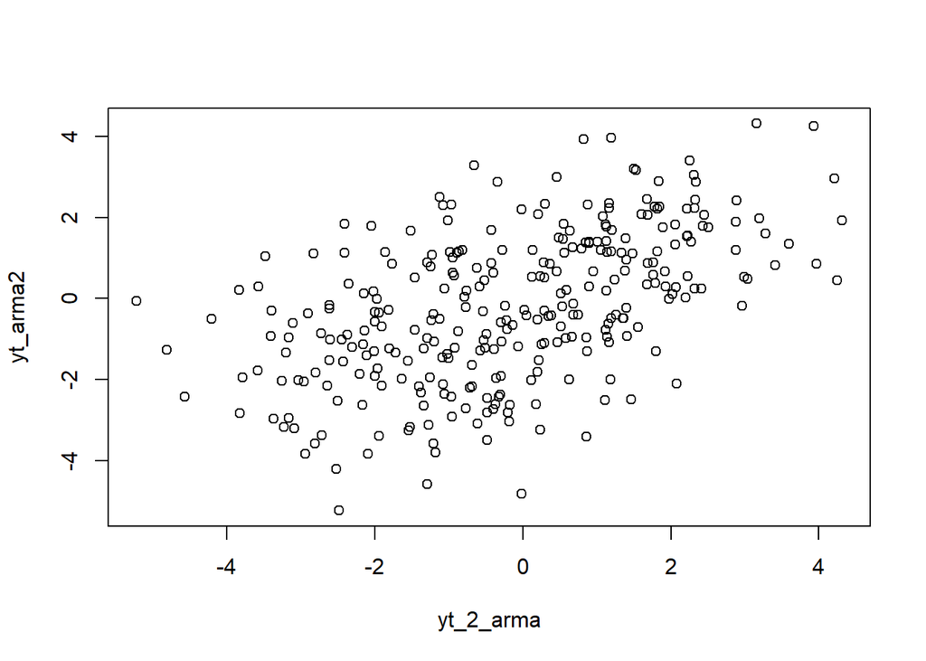

   ```r
   #Plot
   plot(y=yt_arma2,x=yt_2_arma)
   ```

   ```r
   #Korelasi
   cor(yt_arma2,yt_2_arma)
   ```

   ```
   ## [1] 0.5165463
   ```

   Berdasarkan plot tersebut, terlihat hubungan tren positif antara Yt dan Yt-2. Adapun korelasi yang didapatkan sebesar 0.5165463.
7. Scatter Yt dan Yt-3 dan korelasinya

   ```r
   #Yt
   yt_arma3 <- arma11[-c(1,2,3)]
   yt_arma3
   ```

   ```
   ##   [1]  1.35176779 -0.17581640 -0.48580998 -2.61530283 -3.48356186 -1.51233913
   ##   [7]  1.05099693  1.67687161  1.19693725  2.45431360  3.96934346  2.05763565
   ##  [13]  0.84915986  1.33073020  1.37764303  1.12852287  0.68563712  0.20064420
   ##  [19] -0.13435713 -0.52058893 -0.66025843  0.45513261  3.28305975  2.98802538
   ##  [25]  1.60614408  0.54258381  2.08062252  1.46307344 -2.09157852 -2.48817867
   ##  [31] -3.82657046 -5.22247672 -2.82687780 -0.06648461  1.11372612 -1.17595409
   ##  [37] -2.50568225 -3.78987343 -2.51730935 -1.93969913 -4.20649022 -3.39463990
   ##  [43] -0.49374120 -0.29976170 -0.87648866 -0.58434088 -0.81458249  0.29436326
   ##  [49]  1.18870392 -0.29976125 -1.99772918 -1.90468270 -0.57336756 -0.68779557
   ##  [55] -1.27431704 -1.63406802 -3.10748012 -1.97002613 -0.60996158 -0.01332423
   ##  [61] -3.08686758 -4.81076478 -3.19773866 -1.25857935 -1.33589694 -1.94136410
   ##  [67] -1.22386499 -0.34017091  1.07831901  2.87865406  2.02059128  1.18975006
   ##  [73]  0.10966441 -0.47956754 -2.00749938 -2.44557262 -1.29457506 -1.01698710
   ##  [79] -0.98038068  1.92773423  1.15326400  0.29024042 -0.61892227  0.51692849
   ##  [85]  0.74755840  0.12455925 -0.39616302  0.52896452  0.62866310 -0.20124356
   ```

   [output cut: 35 more lines]

   ```r
   #Yt-3
   yt_3_arma <- arma11[-c(298,299,300)]
   yt_3_arma
   ```

   ```
   ##   [1]  4.20792485  3.60063126  2.96280647  1.35176779 -0.17581640 -0.48580998
   ##   [7] -2.61530283 -3.48356186 -1.51233913  1.05099693  1.67687161  1.19693725
   ##  [13]  2.45431360  3.96934346  2.05763565  0.84915986  1.33073020  1.37764303
   ##  [19]  1.12852287  0.68563712  0.20064420 -0.13435713 -0.52058893 -0.66025843
   ##  [25]  0.45513261  3.28305975  2.98802538  1.60614408  0.54258381  2.08062252
   ##  [31]  1.46307344 -2.09157852 -2.48817867 -3.82657046 -5.22247672 -2.82687780
   ##  [37] -0.06648461  1.11372612 -1.17595409 -2.50568225 -3.78987343 -2.51730935
   ##  [43] -1.93969913 -4.20649022 -3.39463990 -0.49374120 -0.29976170 -0.87648866
   ##  [49] -0.58434088 -0.81458249  0.29436326  1.18870392 -0.29976125 -1.99772918
   ##  [55] -1.90468270 -0.57336756 -0.68779557 -1.27431704 -1.63406802 -3.10748012
   ##  [61] -1.97002613 -0.60996158 -0.01332423 -3.08686758 -4.81076478 -3.19773866
   ##  [67] -1.25857935 -1.33589694 -1.94136410 -1.22386499 -0.34017091  1.07831901
   ##  [73]  2.87865406  2.02059128  1.18975006  0.10966441 -0.47956754 -2.00749938
   ##  [79] -2.44557262 -1.29457506 -1.01698710 -0.98038068  1.92773423  1.15326400
   ##  [85]  0.29024042 -0.61892227  0.51692849  0.74755840  0.12455925 -0.39616302
   ```

   [output cut: 35 more lines]

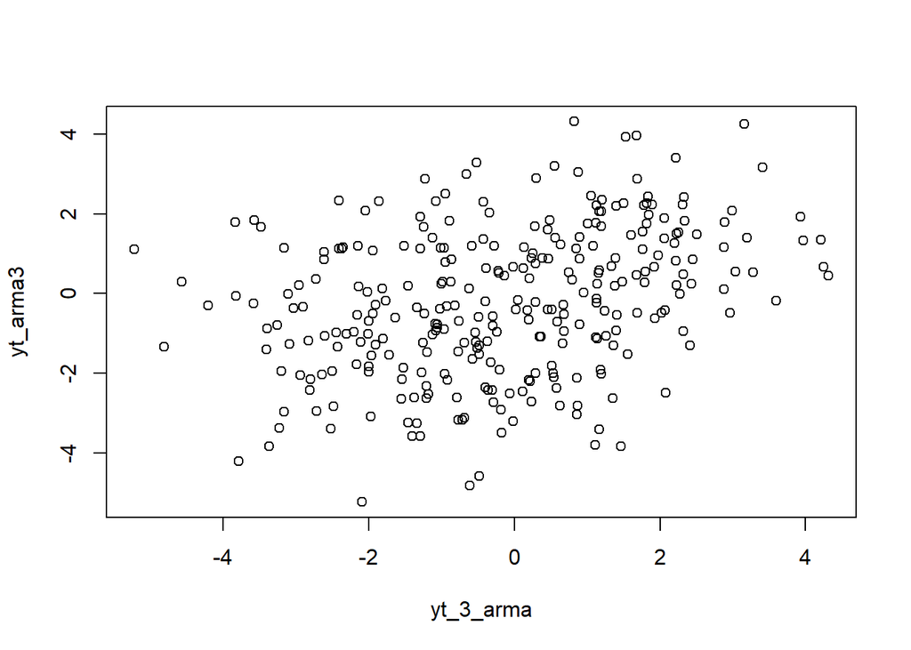

   ```r
   #Plot
   plot(y=yt_arma3,x=yt_3_arma)
   ```

   ```r
   #Korelasi
   cor(yt_arma3,yt_3_arma)
   ```

   ```
   ## [1] 0.3276062
   ```

   Berdasarkan plot tersebut, terlihat hubungan tren positif antara Yt dan Yt-3. Adapun korelasi yang didapatkan sebesar 0.3276062.